# IS: Digitalisation PandaDoc

Author

Victor REGLY

Published

[figure not shown]

[figure not shown]

**Imposition à la source**: Dans le but de réduire le nombre de documents papier, nous introduisons la signature électronique de documents avec PandaDoc, afin de simplifier la procédure des documents d’Impôt à la Source pour les artistes.

## Procédure

### 1. Préparez votre document Excel, une fois prêt : exportez-le en PDF

*Cliquez sur Fichier > Enregistrer Sous… et sélectionnez le format PDF à l’endroit désiré.*

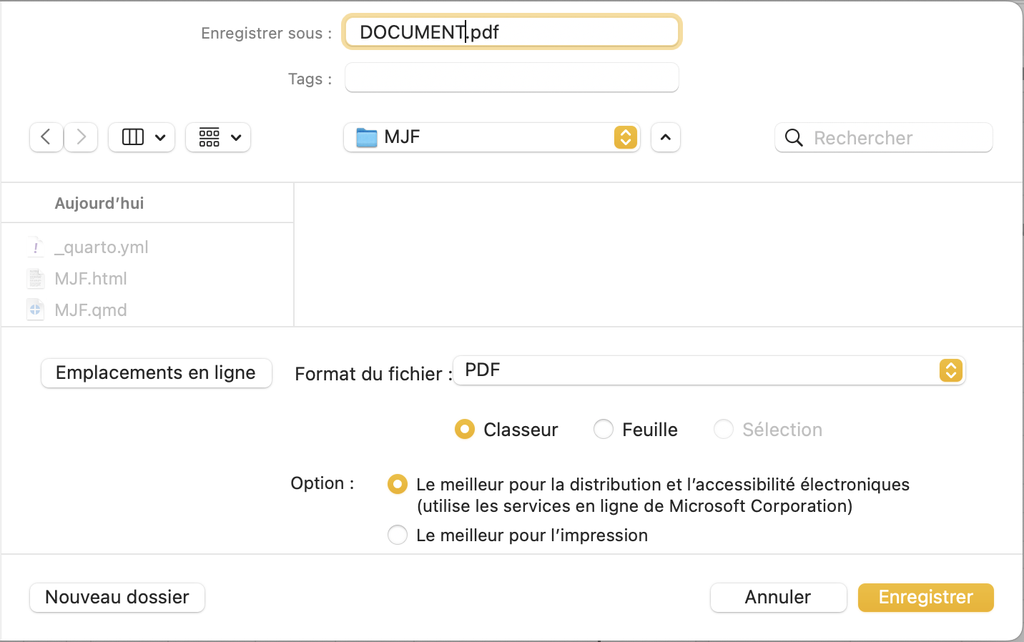

### 2. Création du dossier PDF

Sélectionnez tous les fichiers avec justificatif en sélectionnant l’Excel en PDF en premier : *clic droit* > Action Rapide > Créer PDF

### 3. Ouverture de PandaDoc

Ouvrez PandaDoc en cliquant [ici](https://app.pandadoc.com/a/#/dashboard).

Une fois ouvert, cliquez sur *+ Créer un Document*

[figure not shown]

### 4. Veuillez maintenant glisser le document sélectionné.

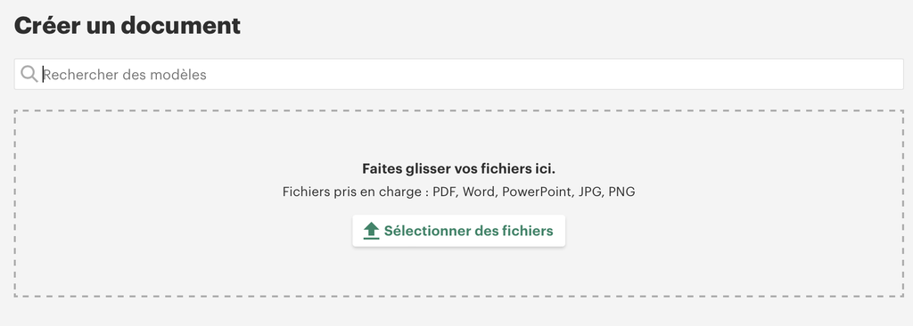

### 5. Vérification du nom du document et du destinataire

Vérifiez le nom du document, exemple : *“IPA_02_KINGS”* Destinataire : Damien Binzoni; *d.binzoni@mjf.ch*

Cliquez sur continuer.

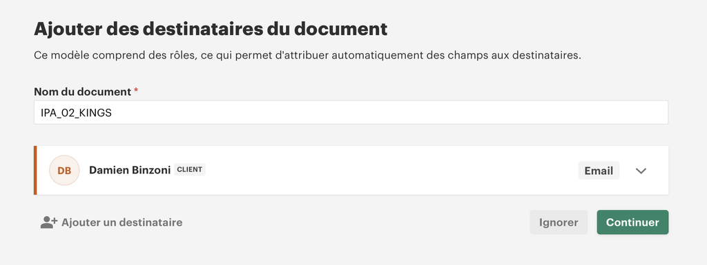

### 6. Poser les zones de signature

Info importante: Signature et Texte

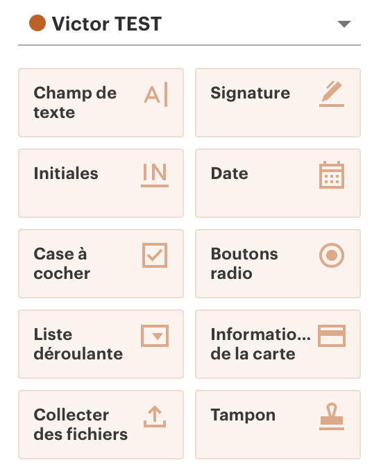

1. Vous devez maintenant déposer sur les **3 fiches** d’impôt à la source, le label signature que vous trouverez sur la droite de l’écran. Appuyez sur *propriétés* pour **enlever la mention obligatoire**.
2. Ajoutez un *Champ de texte* sur la deuxième feuille, pour permettre à Damien de corriger des erreurs si nécessaire. Appuyez sur *propriétés* pour **enlever la mention obligatoire**.
3. Une fois apposé, **appuyez sur envoyer**.

**IMPORTANT**: Appuyez sur *propriétés* pour **enlever la mention obligatoire** dans les deux cas.

### 7. Observer le statut du document

Une fois ces opérations effectuées, observez leur état dans PandaDoc sous *DOCUMENT*:

[figure not shown]

1. Si le statut est *terminé*, vous pouvez vérifier que la signature est bien déposée.
   1. Signature déposée : Exportez le document pour le ranger dans le dossier.
   2. Commentaire sans signature -> corriger l’erreur et recommencer depuis le début.
2. Si le statut est *envoyé* - Damien n’a pas encore ouvert le document.
3. Si le statut est *consulté* - cliquez sur le dossier pour voir s’il y a des commentaires pour des modifications potentielles / attendez.

### 8. Document READY

Vous pouvez maintenant envoyer le document final au manager concerné.